# SIR models

How outbreaks grow, peak, and end

## Last time

Lineages **split** (birth) and **die** (death) at random

Today: The same model, but the “lineages” are **infections**

- An infected person passes the virus on: “birth” of an infection
- An infected person recovers: “death” of an infection

# The SIR model

## Three groups of people<sup>1</sup>

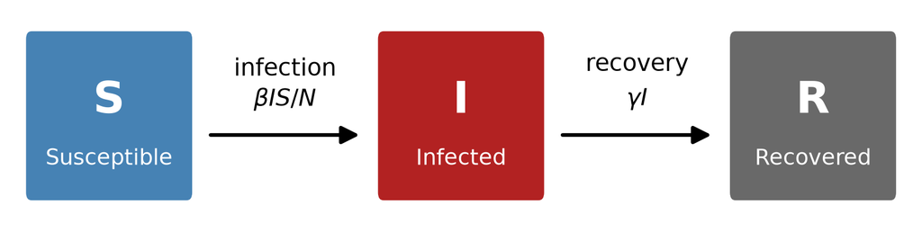

- $N$ people: $S + I + R = N$
- Each infected person recovers at rate $\gamma$ (on average, after $1 / \gamma$ days)
- Each infected person passes on the virus at rate $\beta$, but only a fraction, $S / N$, of the people they meet are susceptible
  - So, transmission rate is $\beta \frac{S}{N}$ per infected person
[^1]: Kermack and McKendrick (1927)

## Compared to a birth-death model

|  | Birth-death | SIR |
| --- | --- | --- |
| What multiplies? | Lineages, $n$ | Infections, $I$ |
| Total rate of “births” | $\lambda n$ | $\beta \frac{S}{N} \cdot I$ |
| Total rate of “deaths” | $\mu n$ | $\gamma I$ |

At the start of an outbreak, $S / N \approx 1$, so it *is* a birth-death process with $\lambda = \beta$ and $\mu = \gamma$

The difference: Each infection “uses up” a susceptible person, so the outbreak slows down as $S$ shrinks

## The basic reproduction number

$R_0$: The average number of people one infected person infects, when everyone else is susceptible

Infects at rate $\beta$, for an average of $1 / \gamma$ days:

$$R_0 = \frac{\beta}{\gamma}$$

**Question**

What do you think happens when $R_0 < 1$? When $R_0 > 1$?

# Simulating an outbreak one event at a time

## The Gillespie algorithm, again<sup>1</sup>

1. Calculate the total (population) rates: infection $\beta I S / N$ and recovery $\gamma I$
2. Draw an exponential **waiting time** using the **total rate**
3. Choose **which event** happened, with probability proportional to its rate
   - Infection: $S - 1$, $I + 1$
   - Recovery: $I - 1$
4. Repeat until $I = 0$

Same recipe as `simulate_birth_death`, with different rates

[^2]: Gillespie (1977)

## Minor and major outbreaks

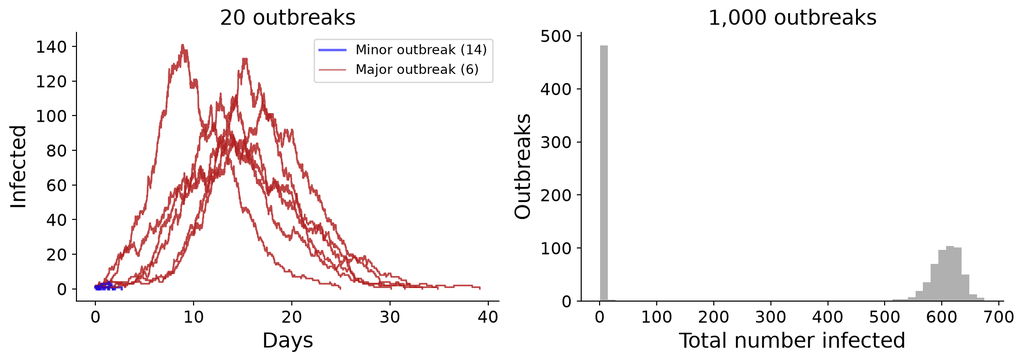

$N = 763$, one infected person, $\beta = 1$, $\gamma = 0.5$ per day ($R_0 = 2$)

## How often does an outbreak fizzle out?

| $R_0$ | Fraction of minor outbreaks (simulated) |
| --- | --- |
| 1.5 | 0.65 |
| 2.0 | 0.52 |
| 3.0 | 0.34 |

**Question**

Last time, a clade starting with one lineage eventually died out with probability $\mu / \lambda$.<sup>1</sup> What should the probability be here?

[^3]: Kendall (1948)

# The average outbreak

## Euler’s method

In a short time $\Delta t$, the **expected** numbers of events are:

$$\text{new infections} = \frac{\beta I S}{N} \Delta t
\qquad
\text{recoveries} = \gamma I \Delta t$$

Update, and repeat, one time step at a time:

$$\begin{aligned}
S &\leftarrow S - \text{new infections} \\
I &\leftarrow I + \text{new infections} - \text{recoveries} \\
R &\leftarrow R + \text{recoveries}
\end{aligned}$$

- Solves the SIR *differential equations*, *e.g.*, $\frac{dI}{dt} = \frac{\beta I S}{N} - \gamma I$
- Smaller $\Delta t$ → closer to the exact solution (but more steps)

## Random outbreaks vs. the average

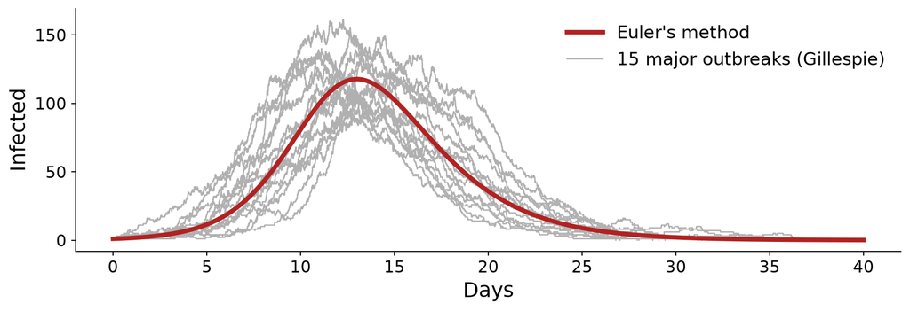

- Major outbreaks have the same **shape**
  - Randomness early on mostly shifts **when** they take off

## Why does an outbreak peak?

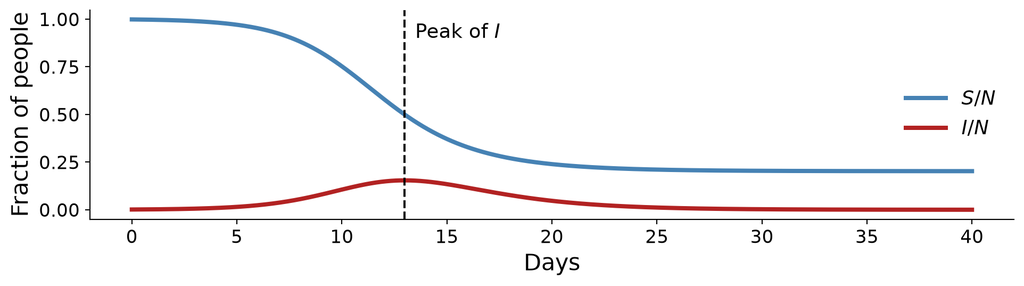

Each infected person infects at rate $\beta S / N$ and recovers at rate $\gamma$

**Question**

What is $S / N$ when $I$ stops growing? (You’ll find out in the capstone!)

# The boarding school

## Influenza at a boarding school, 1978<sup>1</sup>

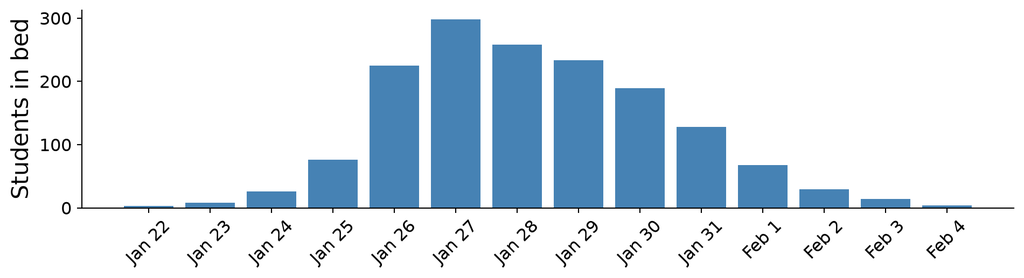

- A strain of H1N1 that hadn’t circulated since the 1950s: no one was immune
- 512 of the school’s 763 students were confined to bed within two weeks
[^4]: Anonymous (1978)

## Fitting the model to the data

For each $\beta$ and $\gamma$, how far are the predictions from the counts?

$$\text{sum of squares} = \sum_{\text{days}} \left(\text{observed} -
\text{predicted}\right)^2$$

- *Least squares*: The best fit has the **smallest** sum of squares (like `linregress` in Capstone 2)
- *Grid search*: Try every combination of $\beta$ and $\gamma$ from two lists, and keep the best

**Watch for**

How contagious was this virus? And why did only 512 students end up in bed?

## Summary

- The **SIR model**: infections at rate $\beta I S / N$, recoveries at rate $\gamma I$
- $R_0 = \beta / \gamma$: the average number of people one case infects
- Near its start, an outbreak is a **birth-death process**, so many outbreaks **fizzle out** by chance
- **Euler’s method** calculates the average course of an outbreak, one small time step at a time
- Fitting the model to data tells us how contagious a virus is

## Capstone 3

1. `simulate_sir`: The Gillespie algorithm for outbreaks
2. `fraction_minor_outbreaks`: How often does an outbreak fizzle out?
3. `simulate_sir_euler` and `plot_sir`: Explore the average outbreak, with sliders
4. `sum_of_squares` and `fit_sir`: Fit the model to the boarding school
5. Extra credit: How many students would the school have needed to vaccinate?

## Capstone 3

1. Log into [molab](https://molab.marimo.io/)
2. [Open Capstone 3 in molab](https://molab.marimo.io/github/phyletica/intro-to-comp-bio/blob/main/notebooks/capstone-03/capstone_3.py)
3. Click “Fork” button

# References

Anonymous. 1978. “Influenza in a Boarding School.” *British Medical Journal* 1 (6112): 587. https://www.ncbi.nlm.nih.gov/pmc/articles/PMC1603269/.

Gillespie, Daniel T. 1977. “Exact Stochastic Simulation of Coupled Chemical Reactions.” *The Journal of Physical Chemistry* 81 (25): 2340–61. https://doi.org/10.1021/j100540a008.

Kendall, David G. 1948. “On the Generalized ‘Birth-and-Death’ Process.” *Annals of Mathematical Statistics* 19 (1): 1–15. https://doi.org/10.1214/aoms/1177730285.

Kermack, William Ogilvy, and Anderson G. McKendrick. 1927. “A Contribution to the Mathematical Theory of Epidemics.” *Proceedings of the Royal Society of London. Series A* 115 (772): 700–721. https://doi.org/10.1098/rspa.1927.0118.

## Acknowledgements

I drafted and iterated on these slides in collaboration with Anthropic’s Claude (Opus 5.5 model).